# StormAnalisys

Kirill Feoktistov

21.02.2015

# The most harmful storm consequences in US

The reports explores U.S. National Oceanic and Atmospheric Administration’s (NOAA) dataset. This dataset contains gathered statistical data on weather events for period 1950-2011 years. It also includes information on healthy and economycal damage.

The report target is to represent the top 10 most dangerous weather events from health and economic points of view. Also aggregated impact data by event type is available. Health damage is calculated as sum of fatal and injure incidents. Economy damage is calculated as sum of crop and property damages.

## Processing data

Loading the dataset. Link availability was checked on Feb 21 13:20 UTC

```r
require("gdata")
require("lattice")
```

```r
fileUrl <- "https://d396qusza40orc.cloudfront.net/repdata%2Fdata%2FStormData.csv.bz2"
fileName <- "repdata_data_StormData.csv.bz2"
victimFields <- list(field = "healthHarm", readable = "Fatal and injured", plotTitle = "Health consequences")
economyFields <- list(field = "economyHarm", readable = "Economy harm, millions dollars", plotTitle = "Economic consequences")
```

```r
if(!file.exists(fileName)){
  download.file(fileUrl,fileName, mode = "wb", method="curl")
}
```

Dataset contains raw data. This section removes splitted spaces, small typos and also casts analised strings to equal case. Also to calculate economyc consequences the multiplier should be used. The multiplier is stored in PROPDMGEXP and CROPDMGEXP columns as character or numeric values. Numeric values means power of 10 (e.g. multiplier 3 means 10^3). Character values: **H**undred, **K**ilo, **M**illion, **B**illion. Other values are assumed as 1.

```r
multiply <- function(val) {
  if (is.numeric(val)) {
    10^val
  } else {
    switch(tolower(val), h=1e2, k = 1e3, m = 1e6, b=1e9, 1)
  }
}

dataset <- read.csv(fileName)
dataset$EVTYPE <- trim(tolower(dataset$EVTYPE))
dataset$EVTYPE <- gsub("/", "", dataset$EVTYPE)
dataset$EVTYPE <- gsub("\\s\\s+", "\\s", dataset$EVTYPE)
dataset$PROPDMGEXP <- sapply(dataset$PROPDMGEXP, multiply)
dataset$CROPDMGEXP <- sapply(dataset$CROPDMGEXP, multiply)

dataset$economyHarm <- (dataset$PROPDMG*dataset$PROPDMGEXP + dataset$CROPDMG*dataset$CROPDMGEXP)/1e6
dataset$healthHarm <- dataset$FATALITIES + dataset$INJURIES
dataset$Year <- format(as.POSIXct(dataset$BGN_DATE, format="%m/%d/%Y %H:%M:%S"), "%Y")
dataset$Location <- paste(trim(toupper(dataset$COUNTYNAME)), trim(toupper(dataset$STATE)), sep=", ")
```

# Results

## Event reports

This section represents the most influent events made impact on health and economy.

### Health influence by event

Top-10 most dangerous weather events

```r
top <- function(dataset, n, field, fieldReadableName) {
  result <- head(dataset[order(-dataset[[field]], dataset$COUNTYNAME), c("EVTYPE", "Year", field)], n)
  result <- as.data.frame(result, row.names = 1:n)
  colnames(result) <- c("Type", "Year", fieldReadableName)
  result
}

top(dataset, 10, victimFields$field, victimFields$readable)
```

```
##                Type Year Fatal and injured
## 1           tornado 1979              1742
## 2         ice storm 1994              1569
## 3           tornado 1953              1318
## 4           tornado 2011              1308
## 5           tornado 1974              1186
## 6           tornado 1953               901
## 7           tornado 2011               844
## 8             flood 1998               802
## 9  hurricanetyphoon 2004               787
## 10            flood 1998               750
```

### Economy harm by event

Top-10 most desctructive events

```r
top(dataset, 10, economyFields$field, economyFields$readable)
```

```
##                Type Year Economy harm, millions dollars
## 1             flood 2006                       115032.5
## 2       storm surge 2005                        31300.0
## 3  hurricanetyphoon 2005                        16930.0
## 4       storm surge 2005                        11260.0
## 5       river flood 1993                        10000.0
## 6  hurricanetyphoon 2005                        10000.0
## 7  hurricanetyphoon 2005                         7390.0
## 8  hurricanetyphoon 2005                         7350.0
## 9  hurricanetyphoon 2004                         5705.0
## 10   tropical storm 2001                         5150.0
```

## Event type reports

This section represents most dangerous event types.

### Victims by event type

Top-10 dangerous event types

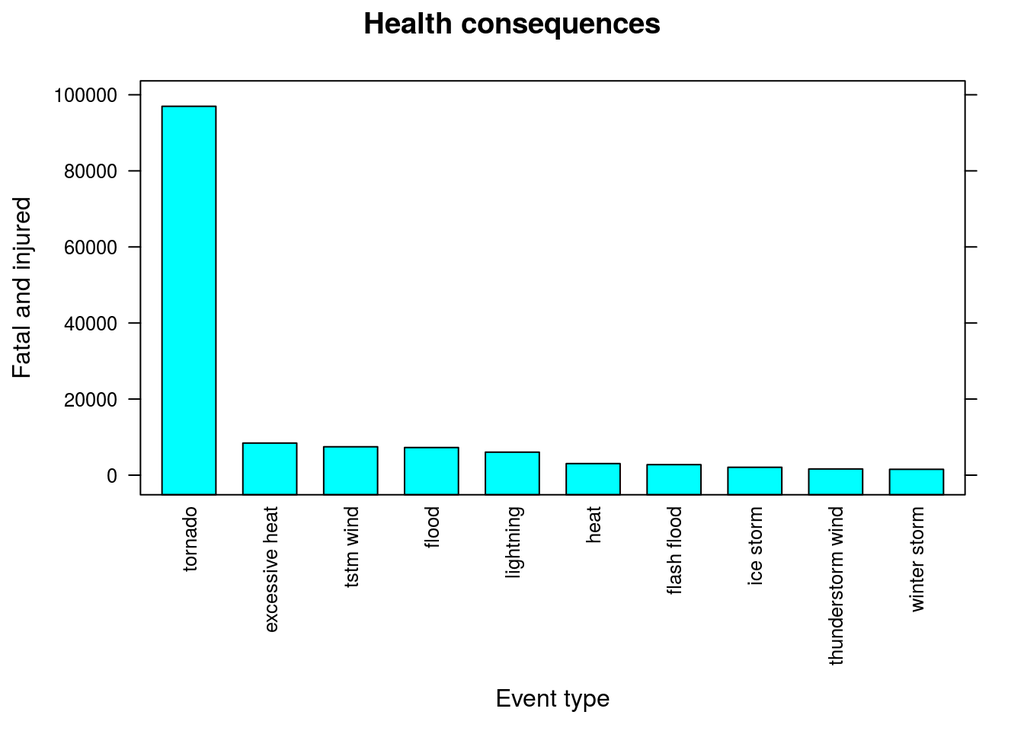

```r
topAggregated <- function(dataset, parameters, n) {
  result <- aggregate(dataset[[parameters$field]] ~ EVTYPE, dataset, sum)
  colnames(result) <- c("Type", parameters$readable)
  result <- head(result[order(-result[[parameters$readable]]), ], n)
  result$Type <- factor(result$Type, levels=unique(result$Type))
  barchart(result[[parameters$readable]]~Type, result, scales=list(x=list(rot=90)), xlab="Event type", ylab = parameters$readable, main=parameters$plotTitle)
}

topAggregated(dataset, victimFields, 10)
```

### Economy harm by event type

Top-10 destructive event types

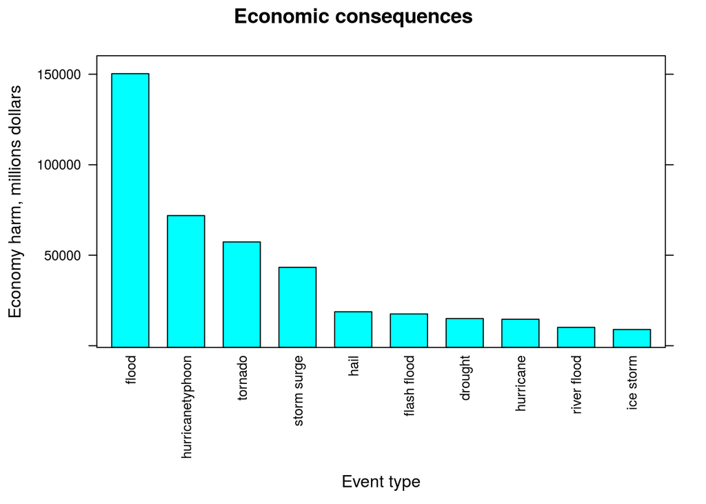

```r
topAggregated(dataset, economyFields, 10)
```

## Conclusion

As shown from the report, the most dangerous weather event is tornado and the flood consequences are the most expensive.